# results03_population-probability-stats

Tommy Botch

2024-11-15

# Setup environment

## Load packages and setup paths for analysis

Set up directories - since we’re doing this locally (and mounting the server), we’re going to use a different base_dir

# Population-level analysis

## Data loading

Load data and set factors. Our columns are the following: - **modality:** which modality was the stimulus presented as (video, audio, text) - **ground_truth:** ground-truth word to be predicted - **top_pred:** most predicted word across the population - **word_index:** the word index within the story - **task:** which of the three stories was the data from (black, wheretheressmoke, howtodraw)

We create a contrast of modality such that we test the hypothesis that multimodal (video) > spoken (audio) > written (text).

```r
results_fn <- file.path(results_dir, "all-task_group-analyzed-behavior_human-lemmatized.csv")

# Load data and convert columns to factors
df_results <- load_and_prepare_data(
  file_path=results_fn,
  factor_columns=c('modality', 'ground_truth', 'top_pred', 'word_index','task',"POS_spaCy", "Clause_Pos", "Clause_ID")
)

# Set the levels for the modality column
df_results <- set_factor_levels(
  df=df_results,
  column_name="modality",
  levels=c("video", "audio", "text")
)

df_results <- create_column_contrast(
  df=df_results,
  column_name="modality",
)
```

## Analysis 1A - Predictability

We first investigate whether predictability (percentage of subjects predicting the correct word) varies based on the modality of the stimulus. We use a linear mixed-effects model with a log-link function, given that predictability is log distributed (e.g., floor is most common).

```r
predictability_formula <- 'predictability ~ modality + (1|word_index:task)'

# Fit the logistic mixed-effects model
model <- glmer(predictability_formula, data=df_results, family=gaussian(link='log'))

tab_model(model, show.se=TRUE, show.stat=TRUE, show.r2=TRUE, show.df=TRUE)
```

|  | predictability |  |  |  |  |  |
| --- | --- | --- | --- | --- | --- | --- |
| Predictors | Estimates | std. Error | CI | Statistic | p | df |
| (Intercept) | -2.63 | 0.07 | -2.77 – -2.50 | -37.21 | **<0.001** | 2011.00 |
| modality L | -0.26 | 0.01 | -0.28 – -0.24 | -25.61 | **<0.001** | 2011.00 |
| modality Q | -0.05 | 0.01 | -0.07 – -0.03 | -5.59 | **<0.001** | 2011.00 |
| Random Effects |  |  |  |  |  |  |
| σ<sup>2</sup> | 0.03 |  |  |  |  |  |
| τ<sub>00</sub> <sub>word_index:task</sub> | 0.92 |  |  |  |  |  |
| ICC | 0.97 |  |  |  |  |  |
| N <sub>word_index</sub> | 594 |  |  |  |  |  |
| N <sub>task</sub> | 3 |  |  |  |  |  |
| Observations | 2016 |  |  |  |  |  |
| Marginal R<sup>2</sup> / Conditional R<sup>2</sup> | 0.024 / 0.970 |  |  |  |  |  |

```r
# Conduct pairwise comparisons between modalities
pairwise_comparisons <- emmeans(model, pairwise ~ modality)
display_pairwise_comparisons(pairwise_comparisons)
```

Pairwise Comparisons

| Comparison Results Comparison | Comparison Results Difference in Mean | Comparison Results Standard Error | Comparison Results Degrees of Freedom | Comparison Results Z-Statistic | Comparison Results P-Value |
| --- | --- | --- | --- | --- | --- |
| video - audio | 0.1186468 | 0.01212013 | Inf | 9.78924 | 3.197442e-14 |
| video - text | 0.3657220 | 0.01427923 | Inf | 25.61217 | 0.000000e+00 |
| audio - text | 0.2470752 | 0.01480555 | Inf | 16.68801 | 0.000000e+00 |

## Analysis 1B - Predictability interaction with prosody

```r
predictability_formula <- 'predictability ~ modality * prominence_mean_words5 + (1|word_index:task)'

# Fit the mixed-effects model
model <- glmer(predictability_formula, data=df_results, family=gaussian(link='log'))

tab_model(model, show.se=TRUE, show.stat=TRUE, show.r2=TRUE, show.df=TRUE)
```

|  | predictability |  |  |  |  |  |
| --- | --- | --- | --- | --- | --- | --- |
| Predictors | Estimates | std. Error | CI | Statistic | p | df |
| (Intercept) | -2.66 | 0.11 | -2.88 – -2.45 | -24.08 | **<0.001** | 2008.00 |
| modality L | -0.23 | 0.02 | -0.27 – -0.19 | -11.87 | **<0.001** | 2008.00 |
| modality Q | -0.02 | 0.02 | -0.05 – 0.02 | -1.05 | 0.293 | 2008.00 |
| prominence mean words5 | 0.06 | 0.18 | -0.30 – 0.42 | 0.31 | 0.754 | 2008.00 |
| modality L × prominence mean words5 | -0.06 | 0.04 | -0.13 – 0.01 | -1.66 | 0.097 | 2008.00 |
| modality Q × prominence mean words5 | -0.07 | 0.03 | -0.13 – -0.01 | -2.18 | **0.029** | 2008.00 |
| Random Effects |  |  |  |  |  |  |
| σ<sup>2</sup> | 0.03 |  |  |  |  |  |
| τ<sub>00</sub> <sub>word_index:task</sub> | 0.92 |  |  |  |  |  |
| ICC | 0.97 |  |  |  |  |  |
| N <sub>word_index</sub> | 594 |  |  |  |  |  |
| N <sub>task</sub> | 3 |  |  |  |  |  |
| Observations | 2016 |  |  |  |  |  |
| Marginal R<sup>2</sup> / Conditional R<sup>2</sup> | 0.024 / 0.970 |  |  |  |  |  |

```r
# Conduct pairwise comparisons between modalities
pairwise_comparisons <- emmeans(model, pairwise ~ modality)
```

```
## NOTE: Results may be misleading due to involvement in interactions
```

```r
display_pairwise_comparisons(pairwise_comparisons)
```

Pairwise Comparisons

| Comparison Results Comparison | Comparison Results Difference in Mean | Comparison Results Standard Error | Comparison Results Degrees of Freedom | Comparison Results Z-Statistic | Comparison Results P-Value |
| --- | --- | --- | --- | --- | --- |
| video - audio | 0.1187596 | 0.01209934 | Inf | 9.815374 | 3.064216e-14 |
| video - text | 0.3661939 | 0.01426465 | Inf | 25.671419 | 0.000000e+00 |
| audio - text | 0.2474344 | 0.01478948 | Inf | 16.730431 | 0.000000e+00 |

### Plot the interaction between predictability and prosody

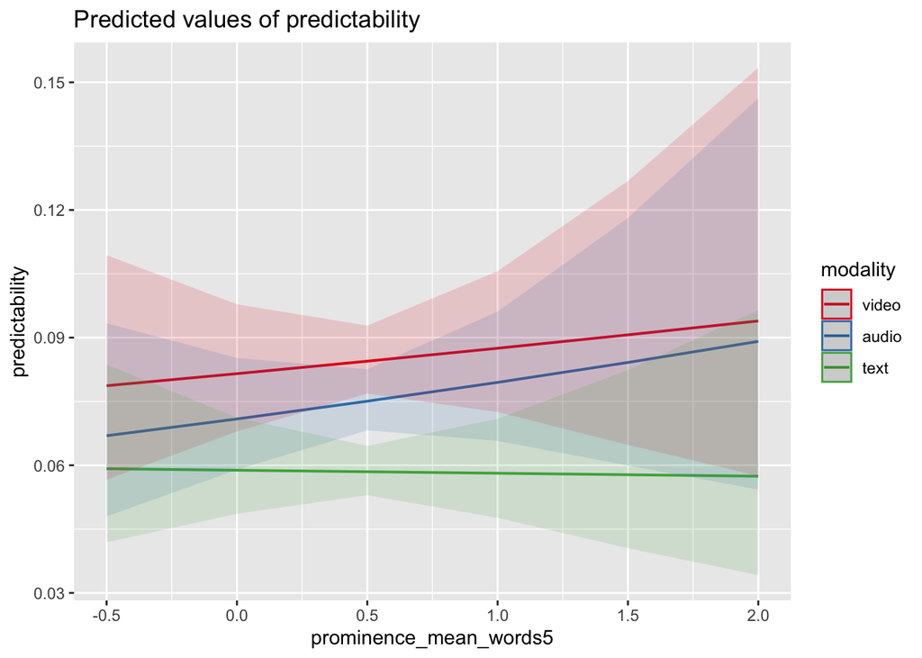

```r
plot_model(model, type='pred', terms=c('prominence_mean_words5', 'modality'))
```

## Analysis 1C - Task-level comparisons

```r
predictability_formula <- 'predictability ~ modality + (1|word_index)'
```

Now conduct the comparisons for each task.

### Story = Black

```r
model <- lmer_task(
  task_name='black',
  df=df_results,
  formula=predictability_formula,
  family=gaussian(link="log")
)

# Output the results
tab_model(model, show.se = TRUE, show.stat = TRUE, show.r2 = TRUE)
```

|  | Dependent variable |  |  |  |  |
| --- | --- | --- | --- | --- | --- |
| Predictors | Estimates | std. Error | CI | Statistic | p |
| (Intercept) | -2.44 | 0.13 | -2.70 – -2.17 | -18.10 | **<0.001** |
| modality L | -0.31 | 0.02 | -0.35 – -0.27 | -15.94 | **<0.001** |
| modality Q | -0.11 | 0.02 | -0.15 – -0.08 | -6.73 | **<0.001** |
| Random Effects |  |  |  |  |  |
| σ<sup>2</sup> | 0.03 |  |  |  |  |
| τ<sub>00</sub> <sub>word_index</sub> | 0.86 |  |  |  |  |
| ICC | 0.96 |  |  |  |  |
| N <sub>word_index</sub> | 194 |  |  |  |  |
| Observations | 582 |  |  |  |  |
| Marginal R<sup>2</sup> / Conditional R<sup>2</sup> | 0.039 / 0.965 |  |  |  |  |

```r
# Conduct pairwise comparisons between modalities
pairwise_comparisons <- emmeans(model, pairwise ~ modality)
display_pairwise_comparisons(pairwise_comparisons)
```

Pairwise Comparisons

| Comparison Results Comparison | Comparison Results Difference in Mean | Comparison Results Standard Error | Comparison Results Degrees of Freedom | Comparison Results Z-Statistic | Comparison Results P-Value |
| --- | --- | --- | --- | --- | --- |
| video - audio | 0.0779632 | 0.02161784 | Inf | 3.606429 | 0.0009058413 |
| video - text | 0.4373111 | 0.02742765 | Inf | 15.944170 | 0.0000000000 |
| audio - text | 0.3593479 | 0.02795769 | Inf | 12.853278 | 0.0000000000 |

### Story = Smoke

```r
model <- lmer_task(
  task_name='wheretheressmoke',
  df=df_results,
  formula=predictability_formula,
  family=gaussian(link="log")
)

# Output the results
tab_model(model, show.se = TRUE, show.stat = TRUE, show.r2 = TRUE)
```

|  | Dependent variable |  |  |  |  |
| --- | --- | --- | --- | --- | --- |
| Predictors | Estimates | std. Error | CI | Statistic | p |
| (Intercept) | -2.57 | 0.12 | -2.80 – -2.34 | -21.58 | **<0.001** |
| modality L | -0.25 | 0.02 | -0.29 – -0.22 | -13.36 | **<0.001** |
| modality Q | 0.02 | 0.02 | -0.02 – 0.06 | 1.08 | 0.282 |
| Random Effects |  |  |  |  |  |
| σ<sup>2</sup> | 0.03 |  |  |  |  |
| τ<sub>00</sub> <sub>word_index</sub> | 0.85 |  |  |  |  |
| ICC | 0.96 |  |  |  |  |
| N <sub>word_index</sub> | 237 |  |  |  |  |
| Observations | 711 |  |  |  |  |
| Marginal R<sup>2</sup> / Conditional R<sup>2</sup> | 0.024 / 0.966 |  |  |  |  |

```r
# Conduct pairwise comparisons between modalities
pairwise_comparisons <- emmeans(model, pairwise ~ modality)
display_pairwise_comparisons(pairwise_comparisons)
```

Pairwise Comparisons

| Comparison Results Comparison | Comparison Results Difference in Mean | Comparison Results Standard Error | Comparison Results Degrees of Freedom | Comparison Results Z-Statistic | Comparison Results P-Value |
| --- | --- | --- | --- | --- | --- |
| video - audio | 0.2048105 | 0.02412073 | Inf | 8.491059 | 2.886580e-14 |
| video - text | 0.3602963 | 0.02696472 | Inf | 13.361766 | 0.000000e+00 |
| audio - text | 0.1554858 | 0.02881567 | Inf | 5.395876 | 2.042922e-07 |

### Story = Draw

```r
model <- lmer_task(
  task_name='howtodraw',
  df=df_results,
  formula=predictability_formula,
  family=gaussian(link="log")
)

# Output the results
tab_model(model, show.se = TRUE, show.stat = TRUE, show.r2 = TRUE)
```

|  | Dependent variable |  |  |  |  |
| --- | --- | --- | --- | --- | --- |
| Predictors | Estimates | std. Error | CI | Statistic | p |
| (Intercept) | -2.87 | 0.11 | -3.10 – -2.65 | -25.37 | **<0.001** |
| modality L | -0.22 | 0.01 | -0.24 – -0.19 | -16.02 | **<0.001** |
| modality Q | -0.06 | 0.01 | -0.08 – -0.03 | -4.64 | **<0.001** |
| Random Effects |  |  |  |  |  |
| σ<sup>2</sup> | 0.02 |  |  |  |  |
| τ<sub>00</sub> <sub>word_index</sub> | 1.03 |  |  |  |  |
| ICC | 0.98 |  |  |  |  |
| N <sub>word_index</sub> | 241 |  |  |  |  |
| Observations | 723 |  |  |  |  |
| Marginal R<sup>2</sup> / Conditional R<sup>2</sup> | 0.016 / 0.979 |  |  |  |  |

```r
# Conduct pairwise comparisons between modalities
pairwise_comparisons <- emmeans(model, pairwise ~ modality)
display_pairwise_comparisons(pairwise_comparisons)
```

Pairwise Comparisons

| Comparison Results Comparison | Comparison Results Difference in Mean | Comparison Results Standard Error | Comparison Results Degrees of Freedom | Comparison Results Z-Statistic | Comparison Results P-Value |
| --- | --- | --- | --- | --- | --- |
| video - audio | 0.08083612 | 0.01650994 | Inf | 4.896209 | 2.920911e-06 |
| video - text | 0.30469271 | 0.01901989 | Inf | 16.019692 | 0.000000e+00 |
| audio - text | 0.22385658 | 0.01955451 | Inf | 11.447824 | 0.000000e+00 |

## Analysis 2A - Entropy

We next look at whether entropy of human prediction distributions varies based on condition.

```r
entropy_formula <- 'entropy ~ modality + (1|word_index:task)'

# Fit the logistic mixed-effects model
model <- lmer(entropy_formula, data = df_results)

tab_model(model, show.se=TRUE, show.stat=TRUE, show.r2=TRUE, show.df=TRUE)
```

|  | entropy |  |  |  |  |  |
| --- | --- | --- | --- | --- | --- | --- |
| Predictors | Estimates | std. Error | CI | Statistic | p | df |
| (Intercept) | 2.06 | 0.03 | 2.00 – 2.12 | 68.13 | **<0.001** | 2011.00 |
| modality L | 0.17 | 0.01 | 0.14 – 0.20 | 11.23 | **<0.001** | 2011.00 |
| modality Q | -0.04 | 0.01 | -0.07 – -0.01 | -2.70 | **0.007** | 2011.00 |
| Random Effects |  |  |  |  |  |  |
| σ<sup>2</sup> | 0.15 |  |  |  |  |  |
| τ<sub>00</sub> <sub>word_index:task</sub> | 0.56 |  |  |  |  |  |
| ICC | 0.79 |  |  |  |  |  |
| N <sub>word_index</sub> | 594 |  |  |  |  |  |
| N <sub>task</sub> | 3 |  |  |  |  |  |
| Observations | 2016 |  |  |  |  |  |
| Marginal R<sup>2</sup> / Conditional R<sup>2</sup> | 0.014 / 0.794 |  |  |  |  |  |

```r
# Display results of fixed effects
display_model_summary(model)
```

Model Fixed Effects Summary

| Predictor | Fixed Effects Results Coefficient Estimate | Fixed Effects Results Standard Error | Fixed Effects Results T-Statistic | Fixed Effects Results P-Value | df |  |
| --- | --- | --- | --- | --- | --- | --- |
| (Intercept) | 2.0590935 | 0.03022410 | 68.127534 | 1.119665e-303 |  | 670.9999 |
| modality.L | 0.1671917 | 0.01488608 | 11.231411 | 4.870972e-28 | 1342.0000 |  |
| modality.Q | -0.0401721 | 0.01488608 | -2.698635 | 7.049787e-03 | 1342.0000 |  |

```r
# Conduct pairwise comparisons between modalities
pairwise_comparisons <- emmeans(model, pairwise ~ modality)
display_pairwise_comparisons(pairwise_comparisons)
```

Pairwise Comparisons

| Comparison Results Comparison | Comparison Results Difference in Mean | Comparison Results Standard Error | Comparison Results Degrees of Freedom | Comparison Results T-Statistic | Comparison Results P-Value |
| --- | --- | --- | --- | --- | --- |
| video - audio | -0.16742294 | 0.0210521 | 1342 | -7.952792 | 1.322276e-13 |
| video - text | -0.23644473 | 0.0210521 | 1342 | -11.231411 | 9.603429e-14 |
| audio - text | -0.06902179 | 0.0210521 | 1342 | -3.278618 | 3.069738e-03 |

## Analysis 2B - Entropy interaction with prosody

Include prosody (prominence_mean) within the model as an interaction effect.

```r
entropy_formula <- 'entropy ~ modality * prominence_mean_words5 + (1|word_index:task)'

# Fit the logistic mixed-effects model
model <- lmer(entropy_formula, data = df_results)

tab_model(model, show.se=TRUE, show.stat=TRUE, show.r2=TRUE, show.df=TRUE)
```

|  | entropy |  |  |  |  |  |
| --- | --- | --- | --- | --- | --- | --- |
| Predictors | Estimates | std. Error | CI | Statistic | p | df |
| (Intercept) | 2.06 | 0.06 | 1.95 – 2.18 | 34.99 | **<0.001** | 2008.00 |
| modality L | 0.12 | 0.03 | 0.07 – 0.18 | 4.29 | **<0.001** | 2008.00 |
| modality Q | -0.10 | 0.03 | -0.16 – -0.04 | -3.42 | **0.001** | 2008.00 |
| prominence mean words5 | -0.01 | 0.10 | -0.22 – 0.20 | -0.09 | 0.927 | 2008.00 |
| modality L × prominence mean words5 | 0.09 | 0.05 | -0.01 – 0.19 | 1.72 | 0.085 | 2008.00 |
| modality Q × prominence mean words5 | 0.12 | 0.05 | 0.02 – 0.22 | 2.37 | **0.018** | 2008.00 |
| Random Effects |  |  |  |  |  |  |
| σ<sup>2</sup> | 0.15 |  |  |  |  |  |
| τ<sub>00</sub> <sub>word_index:task</sub> | 0.57 |  |  |  |  |  |
| ICC | 0.79 |  |  |  |  |  |
| N <sub>word_index</sub> | 594 |  |  |  |  |  |
| N <sub>task</sub> | 3 |  |  |  |  |  |
| Observations | 2016 |  |  |  |  |  |
| Marginal R<sup>2</sup> / Conditional R<sup>2</sup> | 0.014 / 0.795 |  |  |  |  |  |

```r
# Display results of fixed effects
display_model_summary(model)
```

Model Fixed Effects Summary

| Predictor | Fixed Effects Results Coefficient Estimate | Fixed Effects Results Standard Error | Fixed Effects Results T-Statistic | Fixed Effects Results P-Value | df |  |
| --- | --- | --- | --- | --- | --- | --- |
| (Intercept) | 2.063759921 | 0.05898906 | 34.98547131 | 2.496040e-153 |  | 669.9999 |
| modality.L | 0.124371943 | 0.02896124 | 4.29442710 | 1.877661e-05 | 1340.0000 |  |
| modality.Q | -0.099021623 | 0.02896124 | -3.41910829 | 6.471318e-04 | 1340.0000 |  |
| prominence_mean_words5 | -0.009659679 | 0.10483553 | -0.09214127 | 9.266133e-01 | 669.9999 |  |
| modality.L:prominence_mean_words5 | 0.088638117 | 0.05147001 | 1.72213143 | 8.527647e-02 | 1340.0000 |  |
| modality.Q:prominence_mean_words5 | 0.121820264 | 0.05147001 | 2.36682042 | 1.808313e-02 | 1340.0000 |  |

```r
# Conduct pairwise comparisons between modalities
pairwise_comparisons <- emmeans(model, pairwise ~ modality)
```

```
## NOTE: Results may be misleading due to involvement in interactions
```

```r
display_pairwise_comparisons(pairwise_comparisons)
```

Pairwise Comparisons

| Comparison Results Comparison | Comparison Results Difference in Mean | Comparison Results Standard Error | Comparison Results Degrees of Freedom | Comparison Results T-Statistic | Comparison Results P-Value |
| --- | --- | --- | --- | --- | --- |
| video - audio | -0.16742294 | 0.02100077 | 1340 | -7.972228 | 0.000000000 |
| video - text | -0.23644473 | 0.02100077 | 1340 | -11.258860 | 0.000000000 |
| audio - text | -0.06902179 | 0.02100077 | 1340 | -3.286631 | 0.002985904 |

### Plot the interaction between prominence and entropy

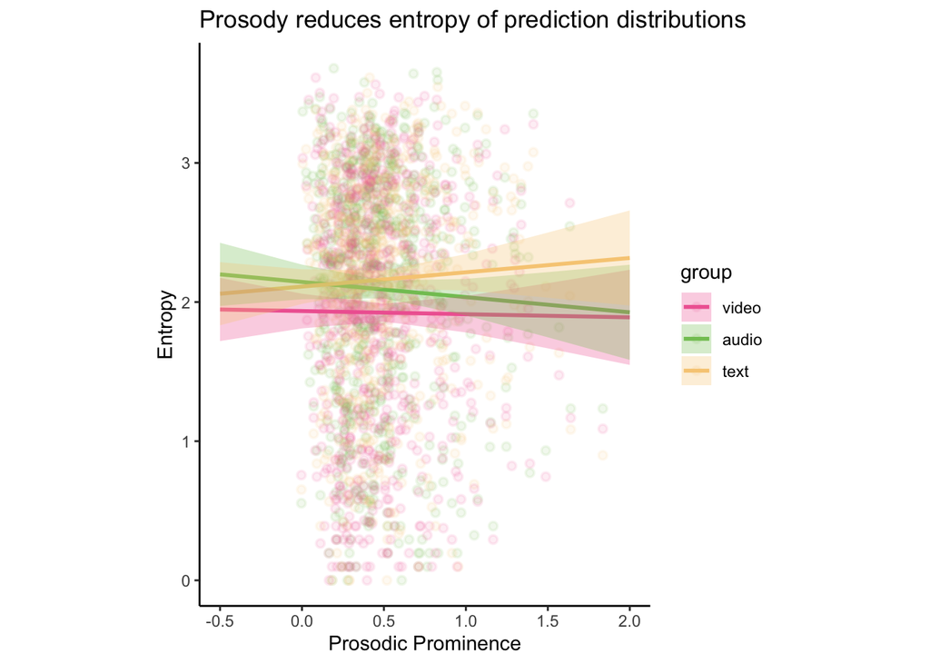

```r
preds <- data.frame(get_model_data(model, type='pred', terms = c("prominence_mean_words5", "modality")))

colors <- c('#F068A1', '#82C564', '#F7CD84')

ggplot(preds, aes(x=x, y=predicted, color=group)) +
  geom_point(
    data = df_results,
    aes(x=prominence_mean_words5, y=entropy, color=modality),
    stroke=1,
    alpha=0.1) +
  geom_line(size=1) +
  geom_ribbon(aes(ymin=conf.low, ymax=conf.high, fill=group), alpha=0.3, color=NA) +
  theme(
    aspect.ratio = 5/4,
    axis.line = element_line(colour = "black"),
    panel.grid.major = element_blank(),
    panel.grid.minor = element_blank(),
    panel.border = element_blank(),
    panel.background = element_blank()
  ) +
  scale_color_manual(values=colors) +
  scale_fill_manual(values=colors) +
  labs(
    x = "Prosodic Prominence",
    y = "Entropy",
    title = "Prosody reduces entropy of prediction distributions")
```

```r
ggsave(file.path(plots_dir, 'human_entropy-prosody-interaction_new.pdf'), device = "pdf")
```

## Analysis 2C - Task-level comparisons

```r
entropy_formula <- 'entropy ~ modality + (1|word_index)'
```

Now conduct the comparisons for each task.

### Story = Black

```r
model <- lmer_task(
  task_name='black',
  df=df_results,
  formula=entropy_formula,
)

# Output the results
tab_model(model, show.se = TRUE, show.stat = TRUE, show.r2 = TRUE)
```

|  | Dependent variable |  |  |  |  |
| --- | --- | --- | --- | --- | --- |
| Predictors | Estimates | std. Error | CI | Statistic | p |
| (Intercept) | 2.00 | 0.06 | 1.89 – 2.12 | 33.99 | **<0.001** |
| modality L | 0.24 | 0.03 | 0.18 – 0.29 | 8.13 | **<0.001** |
| modality Q | 0.03 | 0.03 | -0.03 – 0.09 | 1.10 | 0.270 |
| Random Effects |  |  |  |  |  |
| σ<sup>2</sup> | 0.16 |  |  |  |  |
| τ<sub>00</sub> <sub>word_index</sub> | 0.62 |  |  |  |  |
| ICC | 0.79 |  |  |  |  |
| N <sub>word_index</sub> | 194 |  |  |  |  |
| Observations | 582 |  |  |  |  |
| Marginal R<sup>2</sup> / Conditional R<sup>2</sup> | 0.024 / 0.795 |  |  |  |  |

```r
# Display results of fixed effects
display_model_summary(model)
```

Model Fixed Effects Summary

| Predictor | Fixed Effects Results Coefficient Estimate | Fixed Effects Results Standard Error | Fixed Effects Results T-Statistic | Fixed Effects Results P-Value | df |  |
| --- | --- | --- | --- | --- | --- | --- |
| (Intercept) | 2.00166356 | 0.05889608 | 33.986362 | 2.141522e-83 |  | 193 |
| modality.L | 0.23656333 | 0.02910219 | 8.128713 | 5.959122e-15 | 386 |  |
| modality.Q | 0.03212517 | 0.02910219 | 1.103875 | 2.703351e-01 | 386 |  |

```r
# Conduct pairwise comparisons between modalities
pairwise_comparisons <- emmeans(model, pairwise ~ modality)
display_pairwise_comparisons(pairwise_comparisons)
```

Pairwise Comparisons

| Comparison Results Comparison | Comparison Results Difference in Mean | Comparison Results Standard Error | Comparison Results Degrees of Freedom | Comparison Results T-Statistic | Comparison Results P-Value |
| --- | --- | --- | --- | --- | --- |
| video - audio | -0.1279304 | 0.04115671 | 386 | -3.108373 | 5.719773e-03 |
| video - text | -0.3345511 | 0.04115671 | 386 | -8.128713 | 0.000000e+00 |
| audio - text | -0.2066207 | 0.04115671 | 386 | -5.020340 | 2.358764e-06 |

### Story = Smoke

```r
model <- lmer_task(
  task_name='wheretheressmoke',
  df=df_results,
  formula=entropy_formula,
)

# Output the results
tab_model(model, show.se = TRUE, show.stat = TRUE, show.r2 = TRUE)
```

|  | Dependent variable |  |  |  |  |
| --- | --- | --- | --- | --- | --- |
| Predictors | Estimates | std. Error | CI | Statistic | p |
| (Intercept) | 2.04 | 0.05 | 1.95 – 2.14 | 43.24 | **<0.001** |
| modality L | 0.10 | 0.03 | 0.05 – 0.15 | 3.76 | **<0.001** |
| modality Q | -0.11 | 0.03 | -0.16 – -0.06 | -4.19 | **<0.001** |
| Random Effects |  |  |  |  |  |
| σ<sup>2</sup> | 0.17 |  |  |  |  |
| τ<sub>00</sub> <sub>word_index</sub> | 0.47 |  |  |  |  |
| ICC | 0.74 |  |  |  |  |
| N <sub>word_index</sub> | 237 |  |  |  |  |
| Observations | 711 |  |  |  |  |
| Marginal R<sup>2</sup> / Conditional R<sup>2</sup> | 0.011 / 0.744 |  |  |  |  |

```r
# Display results of fixed effects
display_model_summary(model)
```

Model Fixed Effects Summary

| Predictor | Fixed Effects Results Coefficient Estimate | Fixed Effects Results Standard Error | Fixed Effects Results T-Statistic | Fixed Effects Results P-Value | df |  |
| --- | --- | --- | --- | --- | --- | --- |
| (Intercept) | 2.04327498 | 0.04725142 | 43.242614 | 3.784341e-114 |  | 236 |
| modality.L | 0.09952191 | 0.02644502 | 3.763351 | 1.887642e-04 | 472 |  |
| modality.Q | -0.11089821 | 0.02644502 | -4.193538 | 3.280686e-05 | 472 |  |

```r
# Conduct pairwise comparisons between modalities
pairwise_comparisons <- emmeans(model, pairwise ~ modality)
display_pairwise_comparisons(pairwise_comparisons)
```

Pairwise Comparisons

| Comparison Results Comparison | Comparison Results Difference in Mean | Comparison Results Standard Error | Comparison Results Degrees of Freedom | Comparison Results T-Statistic | Comparison Results P-Value |
| --- | --- | --- | --- | --- | --- |
| video - audio | -0.20619463 | 0.03739891 | 472 | -5.513386 | 1.738761e-07 |
| video - text | -0.14074523 | 0.03739891 | 472 | -3.763351 | 5.526058e-04 |
| audio - text | 0.06544939 | 0.03739891 | 472 | 1.750035 | 1.878521e-01 |

### Story = Draw

```r
model <- lmer_task(
  task_name='howtodraw',
  df=df_results,
  formula=entropy_formula,
)

# Output the results
tab_model(model, show.se = TRUE, show.stat = TRUE, show.r2 = TRUE)
```

|  | Dependent variable |  |  |  |  |
| --- | --- | --- | --- | --- | --- |
| Predictors | Estimates | std. Error | CI | Statistic | p |
| (Intercept) | 2.12 | 0.05 | 2.02 – 2.22 | 40.90 | **<0.001** |
| modality L | 0.18 | 0.02 | 0.14 – 0.22 | 8.24 | **<0.001** |
| modality Q | -0.03 | 0.02 | -0.07 – 0.01 | -1.33 | 0.182 |
| Random Effects |  |  |  |  |  |
| σ<sup>2</sup> | 0.11 |  |  |  |  |
| τ<sub>00</sub> <sub>word_index</sub> | 0.61 |  |  |  |  |
| ICC | 0.84 |  |  |  |  |
| N <sub>word_index</sub> | 241 |  |  |  |  |
| Observations | 723 |  |  |  |  |
| Marginal R<sup>2</sup> / Conditional R<sup>2</sup> | 0.015 / 0.847 |  |  |  |  |

```r
# Display results of fixed effects
display_model_summary(model)
```

Model Fixed Effects Summary

| Predictor | Fixed Effects Results Coefficient Estimate | Fixed Effects Results Standard Error | Fixed Effects Results T-Statistic | Fixed Effects Results P-Value | df |  |
| --- | --- | --- | --- | --- | --- | --- |
| (Intercept) | 2.12087932 | 0.05185547 | 40.899818 | 3.676033e-110 |  | 240 |
| modality.L | 0.17789554 | 0.02158766 | 8.240613 | 1.646094e-15 | 480 |  |
| modality.Q | -0.02881768 | 0.02158766 | -1.334915 | 1.825371e-01 | 480 |  |

```r
# Conduct pairwise comparisons between modalities
pairwise_comparisons <- emmeans(model, pairwise ~ modality)
display_pairwise_comparisons(pairwise_comparisons)
```

Pairwise Comparisons

| Comparison Results Comparison | Comparison Results Difference in Mean | Comparison Results Standard Error | Comparison Results Degrees of Freedom | Comparison Results T-Statistic | Comparison Results P-Value |
| --- | --- | --- | --- | --- | --- |
| video - audio | -0.16108545 | 0.03052956 | 480 | -5.276377 | 5.981348e-07 |
| video - text | -0.25158229 | 0.03052956 | 480 | -8.240613 | 5.166334e-11 |
| audio - text | -0.09049684 | 0.03052956 | 480 | -2.964237 | 8.924010e-03 |

## Supplementary Analysis - Leakage filtering

```r
df_results_filtered <- subset(df_results, !df_results$filter_for_leakage)
```

### Supplementary Analysis 1A - Predictability

```r
predictability_formula <- 'predictability ~ modality + (1|word_index:task)'

# Fit the mixed-effects model
model <- glmer(predictability_formula, data=df_results_filtered, family=gaussian(link='log'))

tab_model(model, show.se=TRUE, show.stat=TRUE, show.r2=TRUE, show.df=TRUE)
```

|  | predictability |  |  |  |  |  |
| --- | --- | --- | --- | --- | --- | --- |
| Predictors | Estimates | std. Error | CI | Statistic | p | df |
| (Intercept) | -2.61 | 0.07 | -2.75 – -2.46 | -34.90 | **<0.001** | 1798.00 |
| modality L | -0.24 | 0.01 | -0.26 – -0.22 | -23.63 | **<0.001** | 1798.00 |
| modality Q | -0.05 | 0.01 | -0.06 – -0.03 | -4.75 | **<0.001** | 1798.00 |
| Random Effects |  |  |  |  |  |  |
| σ<sup>2</sup> | 0.03 |  |  |  |  |  |
| τ<sub>00</sub> <sub>word_index:task</sub> | 0.93 |  |  |  |  |  |
| ICC | 0.97 |  |  |  |  |  |
| N <sub>word_index</sub> | 537 |  |  |  |  |  |
| N <sub>task</sub> | 3 |  |  |  |  |  |
| Observations | 1803 |  |  |  |  |  |
| Marginal R<sup>2</sup> / Conditional R<sup>2</sup> | 0.020 / 0.970 |  |  |  |  |  |

```r
# Conduct pairwise comparisons between modalities
pairwise_comparisons <- emmeans(model, pairwise ~ modality)
display_pairwise_comparisons(pairwise_comparisons)
```

Pairwise Comparisons

| Comparison Results Comparison | Comparison Results Difference in Mean | Comparison Results Standard Error | Comparison Results Degrees of Freedom | Comparison Results Z-Statistic | Comparison Results P-Value |
| --- | --- | --- | --- | --- | --- |
| video - audio | 0.1143759 | 0.01239830 | Inf | 9.225127 | 3.341771e-14 |
| video - text | 0.3397731 | 0.01437728 | Inf | 23.632637 | 0.000000e+00 |
| audio - text | 0.2253972 | 0.01491710 | Inf | 15.109983 | 0.000000e+00 |

### Supplementary Analysis 2A - Entropy

```r
entropy_formula <- 'entropy ~ modality + (1|word_index:task)'

# Fit the logistic mixed-effects model
model <- lmer(entropy_formula, data = df_results_filtered)

tab_model(model, show.se=TRUE, show.stat=TRUE, show.r2=TRUE, show.df=TRUE)
```

|  | entropy |  |  |  |  |  |
| --- | --- | --- | --- | --- | --- | --- |
| Predictors | Estimates | std. Error | CI | Statistic | p | df |
| (Intercept) | 2.03 | 0.03 | 1.96 – 2.09 | 62.08 | **<0.001** | 1798.00 |
| modality L | 0.16 | 0.02 | 0.13 – 0.19 | 10.54 | **<0.001** | 1798.00 |
| modality Q | -0.04 | 0.02 | -0.07 – -0.01 | -2.56 | **0.010** | 1798.00 |
| Random Effects |  |  |  |  |  |  |
| σ<sup>2</sup> | 0.14 |  |  |  |  |  |
| τ<sub>00</sub> <sub>word_index:task</sub> | 0.59 |  |  |  |  |  |
| ICC | 0.81 |  |  |  |  |  |
| N <sub>word_index</sub> | 537 |  |  |  |  |  |
| N <sub>task</sub> | 3 |  |  |  |  |  |
| Observations | 1803 |  |  |  |  |  |
| Marginal R<sup>2</sup> / Conditional R<sup>2</sup> | 0.012 / 0.810 |  |  |  |  |  |

```r
# Display results of fixed effects
display_model_summary(model)
```

Model Fixed Effects Summary

| Predictor | Fixed Effects Results Coefficient Estimate | Fixed Effects Results Standard Error | Fixed Effects Results T-Statistic | Fixed Effects Results P-Value | df |  |
| --- | --- | --- | --- | --- | --- | --- |
| (Intercept) | 2.02546937 | 0.03262568 | 62.082059 | 2.285466e-263 |  | 600 |
| modality.L | 0.16173958 | 0.01535008 | 10.536727 | 6.873423e-25 | 1200 |  |
| modality.Q | -0.03934926 | 0.01535008 | -2.563457 | 1.048456e-02 | 1200 |  |

```r
# Conduct pairwise comparisons between modalities
pairwise_comparisons <- emmeans(model, pairwise ~ modality)
display_pairwise_comparisons(pairwise_comparisons)
```

Pairwise Comparisons

| Comparison Results Comparison | Comparison Results Difference in Mean | Comparison Results Standard Error | Comparison Results Degrees of Freedom | Comparison Results T-Statistic | Comparison Results P-Value |
| --- | --- | --- | --- | --- | --- |
| video - audio | -0.16255996 | 0.02170829 | 1200 | -7.488382 | 5.898615e-13 |
| video - text | -0.22873431 | 0.02170829 | 1200 | -10.536727 | 1.944001e-13 |
| audio - text | -0.06617435 | 0.02170829 | 1200 | -3.048345 | 6.643279e-03 |